# Project Python Foundations: FoodHub Data Analysis

### Context

The number of restaurants in New York is increasing day by day. Lots of students and busy professionals rely on those restaurants due to their hectic lifestyles. Online food delivery service is a great option for them. It provides them with good food from their favorite restaurants. A food aggregator company FoodHub offers access to multiple restaurants through a single smartphone app.

The app allows the restaurants to receive a direct online order from a customer. The app assigns a delivery person from the company to pick up the order after it is confirmed by the restaurant. The delivery person then uses the map to reach the restaurant and waits for the food package. Once the food package is handed over to the delivery person, he/she confirms the pick-up in the app and travels to the customer's location to deliver the food. The delivery person confirms the drop-off in the app after delivering the food package to the customer. The customer can rate the order in the app. The food aggregator earns money by collecting a fixed margin of the delivery order from the restaurants.

### Objective

The food aggregator company has stored the data of the different orders made by the registered customers in their online portal. They want to analyze the data to get a fair idea about the demand of different restaurants which will help them in enhancing their customer experience. Suppose you are hired as a Data Scientist in this company and the Data Science team has shared some of the key questions that need to be answered. Perform the data analysis to find answers to these questions that will help the company to improve the business.

### Data Description

The data contains the different data related to a food order. The detailed data dictionary is given below.

### Data Dictionary

- order_id: Unique ID of the order
- customer_id: ID of the customer who ordered the food
- restaurant_name: Name of the restaurant
- cuisine_type: Cuisine ordered by the customer
- cost_of_the_order: Cost of the order
- day_of_the_week: Indicates whether the order is placed on a weekday or weekend (The weekday is from Monday to Friday and the weekend is Saturday and Sunday)
- rating: Rating given by the customer out of 5
- food_preparation_time: Time (in minutes) taken by the restaurant to prepare the food. This is calculated by taking the difference between the timestamps of the restaurant's order confirmation and the delivery person's pick-up confirmation.
- delivery_time: Time (in minutes) taken by the delivery person to deliver the food package. This is calculated by taking the difference between the timestamps of the delivery person's pick-up confirmation and drop-off information

### Let us start by importing the required libraries

# Stefhany Rodriguez project #1

```python
# import libraries for data manipulation
import numpy as np
import pandas as pd

# import libraries for data visualization
import matplotlib.pyplot as plt
import seaborn as sns
```

### Understanding the structure of the data

```python
# Write your code here to read the data

#Reading the data from the folder of my posgraduate program
df = pd.read_csv("/Users/stefhanyrodriguez/Documents/Data science & business analytics/Project python foundation/foodhub_order.csv")
```

```python
# Write your code here to view the first 5 rows
df.head(5)
```

|  | order_id | customer_id | restaurant_name | cuisine_type | cost_of_the_order | day_of_the_week | rating | food_preparation_time | delivery_time |
| --- | --- | --- | --- | --- | --- | --- | --- | --- | --- |
| 0 | 1477147 | 337525 | Hangawi | Korean | 30.75 | Weekend | Not given | 25 | 20 |
| 1 | 1477685 | 358141 | Blue Ribbon Sushi Izakaya | Japanese | 12.08 | Weekend | Not given | 25 | 23 |
| 2 | 1477070 | 66393 | Cafe Habana | Mexican | 12.23 | Weekday | 5 | 23 | 28 |
| 3 | 1477334 | 106968 | Blue Ribbon Fried Chicken | American | 29.20 | Weekend | 3 | 25 | 15 |
| 4 | 1478249 | 76942 | Dirty Bird to Go | American | 11.59 | Weekday | 4 | 25 | 24 |

### **Question 1:** How many rows and columns are present in the data? [0.5 mark]

```python
# Write your code here

#shape returns a tuple with the number of rows and columns
rows, columns = df.shape
print('The dataset has', rows, 'rows.')
print('The dataset has', columns, 'columns.')
```

```
The dataset has 1898 rows.
The dataset has 9 columns.
```

#### Observations:

The data frame has 1898 rows and 9 columns

### **Question 2:** What are the datatypes of the different columns in the dataset? (The info() function can be used) [0.5 mark]

```python
# Write your code here

#dtypes is used to see data types of each column
data_types_column = df.dtypes
print(data_types_column)
```

```
order_id                   int64
customer_id                int64
restaurant_name           object
cuisine_type              object
cost_of_the_order        float64
day_of_the_week           object
rating                    object
food_preparation_time      int64
delivery_time              int64
dtype: object
```

#### Observations:

- There are 3 datatypes present in the dataset: integer, float and object.
- Order_id, customer_id, food_preparation_time, delivery_time are integer type columns.
- Restaurant_name, cuisine_type, day_of_the_week, rating are object type columns.
- cost_of_the_order is a float type column.

### **Question 3:** Are there any missing values in the data? If yes, treat them using an appropriate method. [1 mark]

```python
# Write your code here
missing_values = df.isnull().sum()
print(missing_values)
print('')
it_has_missing_values = df.isnull().sum().any()
print("Are there any missing values: true or false?", it_has_missing_values)
```

```
order_id                 0
customer_id              0
restaurant_name          0
cuisine_type             0
cost_of_the_order        0
day_of_the_week          0
rating                   0
food_preparation_time    0
delivery_time            0
dtype: int64

Are there any missing values: true or false? False
```

#### Observations:

There are no missing values in the data set.

### **Question 4:** Check the statistical summary of the data. What is the minimum, average, and maximum time it takes for food to be prepared once an order is placed? [2 marks]

```python
# Write your code here
#.describe() gives a summary statistical for a numerical column by default
# include = 'all' to include numerical and categorical column
df.describe(include='all')
```

|  | order_id | customer_id | restaurant_name | cuisine_type | cost_of_the_order | day_of_the_week | rating | food_preparation_time | delivery_time |
| --- | --- | --- | --- | --- | --- | --- | --- | --- | --- |
| count | 1.898000e+03 | 1898.000000 | 1898 | 1898 | 1898.000000 | 1898 | 1898 | 1898.000000 | 1898.000000 |
| unique | NaN | NaN | 178 | 14 | NaN | 2 | 4 | NaN | NaN |
| top | NaN | NaN | Shake Shack | American | NaN | Weekend | Not given | NaN | NaN |
| freq | NaN | NaN | 219 | 584 | NaN | 1351 | 736 | NaN | NaN |
| mean | 1.477496e+06 | 171168.478398 | NaN | NaN | 16.498851 | NaN | NaN | 27.371970 | 24.161749 |
| std | 5.480497e+02 | 113698.139743 | NaN | NaN | 7.483812 | NaN | NaN | 4.632481 | 4.972637 |
| min | 1.476547e+06 | 1311.000000 | NaN | NaN | 4.470000 | NaN | NaN | 20.000000 | 15.000000 |
| 25% | 1.477021e+06 | 77787.750000 | NaN | NaN | 12.080000 | NaN | NaN | 23.000000 | 20.000000 |
| 50% | 1.477496e+06 | 128600.000000 | NaN | NaN | 14.140000 | NaN | NaN | 27.000000 | 25.000000 |
| 75% | 1.477970e+06 | 270525.000000 | NaN | NaN | 22.297500 | NaN | NaN | 31.000000 | 28.000000 |
| max | 1.478444e+06 | 405334.000000 | NaN | NaN | 35.410000 | NaN | NaN | 35.000000 | 33.000000 |

#### Observations:

- Order_id and customer_id are identifiers.
- Food preparation time has a minimum value of 20 minutes and a maximum value of 35 minutes.
- In average it takes 27.37 minutes for food to be prepared once an order is placed. It has a standard deviation of 4.6 minutes. The spread is not very high for food preparation.
- The cost of the order in average is 16.5 dollars and it has a minimum of 4.47 and a maximum of 35.4 dollars.
- Delivery time ranges from 15 minutes to 33 minutes maximum. In average the delivery time is 24.2 minutes with a standard deviation of almost 5 minutes.
- The most frequent category for restaurant_name is Shake Shack, for cuisine type is American, for day of the week is weekend and for rating is 'Not given'.

### **Question 5:** How many orders are not rated? [1 mark]

```python
# Write the code here

#Value counts is useful to count the frequency of each value of a column in a dataframe
count_ratings = df['rating'].value_counts(ascending=True)

#Normalize to have the percetanges of each value
percetage_count_ratings = (df['rating'].value_counts(normalize=True, ascending=True))*100

print(count_ratings)
print('')
print(percetage_count_ratings)
```

```
rating
3            188
4            386
5            588
Not given    736
Name: count, dtype: int64

rating
3             9.905163
4            20.337197
5            30.979979
Not given    38.777661
Name: proportion, dtype: float64
```

#### Observations:

- There are 736 orders that are not rated.
- 'Not given' rating represents the 38.77% of the orders rated.

### Exploratory Data Analysis (EDA)

### **Question 6:** Explore all the variables and provide observations on their distributions. (Generally, histograms, boxplots, countplots, etc. are used for univariate exploration.) [9 marks]

### Order id

```python
# check the total number of unique values
df['order_id'].nunique()
```

```
1898
```

#### Observations:

- There are 1898 order id's. As it's known is just an identifier for each order.

```python
# check if there's any duplicated orders
df['order_id'].duplicated().sum()
```

```
0
```

- As expected, order id should be ideally unique and it is.

### Customer id

```python
df['customer_id'].nunique()
```

```
1200
```

#### Observations:

- There are a significant number of customers that have placed more than one order which explains why the count is less than the number

of order_id. Customer_id is an identifier as well as order_id.

```python
# check if there's any duplicated customer id
df['customer_id'].duplicated().sum()
```

```
698
```

- There's 698 customer_id's duplicated which is consistent since there's only 1200 unique values for a total of 1898 values as expected.

```python
# Check how many orders a customer has placed
df.groupby('customer_id')['order_id'].nunique()
```

```
customer_id
1311      1
5139      1
5444      1
5693      1
6987      2
         ..
402215    1
403019    1
403833    1
404649    1
405334    1
Name: order_id, Length: 1200, dtype: int64
```

- By grouping customer id and order id is posible to check how many unique orders each customer has made and in this way we can check how frequent a customer is.

### Restaurant name

```python
df['restaurant_name'].nunique()
```

```
178
```

#### Observations:

There are 178 unique restaurants in the data set

```python
df['restaurant_name'].value_counts()
```

```
restaurant_name
Shake Shack                  219
The Meatball Shop            132
Blue Ribbon Sushi            119
Blue Ribbon Fried Chicken     96
Parm                          68
                            ...
Sushi Choshi                   1
Dos Caminos Soho               1
La Follia                      1
Philippe Chow                  1
'wichcraft                     1
Name: count, Length: 178, dtype: int64
```

#### Observations:

Shake shack restaurant has recieved the maximum number of orders. It is the most popular restaurant in the data set.

```python
top_5_restaurants = df['restaurant_name'].value_counts().head(5)
print(top_5_restaurants)
```

```
restaurant_name
Shake Shack                  219
The Meatball Shop            132
Blue Ribbon Sushi            119
Blue Ribbon Fried Chicken     96
Parm                          68
Name: count, dtype: int64
```

- The top 5 restaurants in the data set are: Shake Shack, The Meatball Shop, Blue Ribbon Sushi, Blue Ribbon Fried Chicken and Parm.

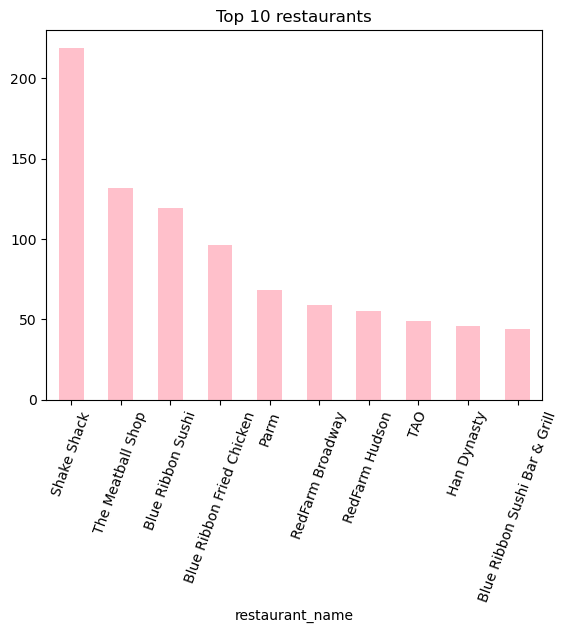

```python
top_10_restaurants = df['restaurant_name'].value_counts().head(10)
top_10_restaurants.plot(kind='bar', color='pink')
plt.xticks(rotation=70)
plt.title('Top 10 restaurants')
```

- Since it is a categorical variable with 178 uniques values, I chose to display just the top 10 in order the visualize the data

and the distribution.

### Cuisine type

```python
df['cuisine_type'].nunique()
```

```
14
```

- There are 14 unique cuisines.

[output not shown]

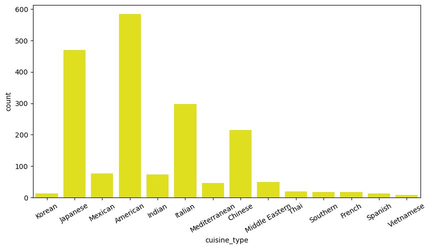

```python
plt.figure(figsize=(10,5))
sns.countplot(data=df, x='cuisine_type', color='yellow')
plt.xticks(rotation=30)
```

```python
df['cuisine_type'].value_counts()
```

```
cuisine_type
American          584
Japanese          470
Italian           298
Chinese           215
Mexican            77
Indian             73
Middle Eastern     49
Mediterranean      46
Thai               19
French             18
Southern           17
Korean             13
Spanish            12
Vietnamese          7
Name: count, dtype: int64
```

```python
(df['cuisine_type'].value_counts(normalize=True))*100
```

```
cuisine_type
American          30.769231
Japanese          24.762908
Italian           15.700738
Chinese           11.327713
Mexican            4.056902
Indian             3.846154
Middle Eastern     2.581665
Mediterranean      2.423604
Thai               1.001054
French             0.948367
Southern           0.895680
Korean             0.684932
Spanish            0.632244
Vietnamese         0.368809
Name: proportion, dtype: float64
```

#### Observations:

- The distribution of cuisine types show that are not equally distributed.
- The most frequent cuisine is American with 30.8% followed by Japanese with 24.8% and Italian cuisine 15.7%.
- Spanish and Vietnamese cuisines are the least popular with 0.63% and 0.37% respectively.

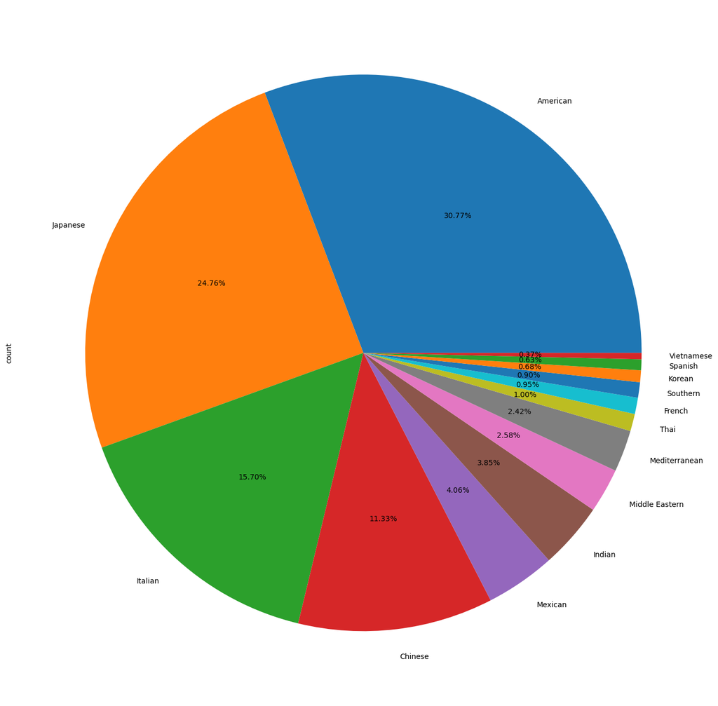

```python
# Plotting pie chart. autopct formating the percentage with two decimal values
df['cuisine_type'].value_counts().plot(kind='pie', autopct='%1.2f%%',figsize=(17,20))
```

- By looking at the pie chart it is easier to analyze that Japanese and American cuisines are the most popular taking half of the graph. These two are the most representative in the chart.
- The percentage represent the portion each cuisine represent relative to the total.

### Cost of the order

```python
df['cost_of_the_order'].nunique()
```

```
312
```

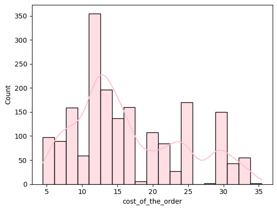

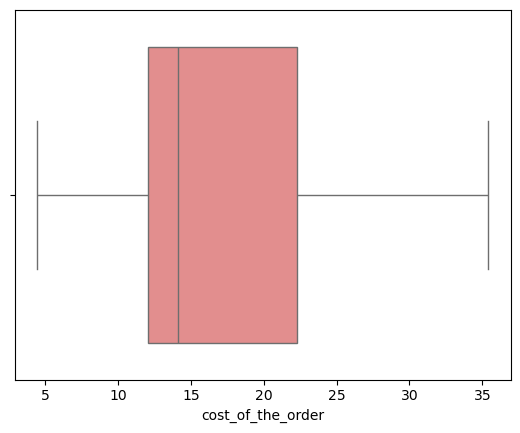

```python
sns.histplot(data=df, x='cost_of_the_order', kde=True, color='Pink')
plt.show()
sns.boxplot(data=df, x='cost_of_the_order', color= 'lightcoral')
plt.show()
```

#### Observations:

- The mean cost of the order is greater than the median and it indicates that it has a right skewed distribution.
- The plot (histogram) shows a tail extending to the right.
- Most of people prefer to order food that cost between 11 and 12 dollars.
- There are few orders that cost more than 30 dollars.
- There's no outliers.

### Day of the week

```python
df['day_of_the_week'].value_counts()
```

```
day_of_the_week
Weekend    1351
Weekday     547
Name: count, dtype: int64
```

- There are 1351 orders placed during the weekend and 547 placed during week days.

```python
(round(df['day_of_the_week'].value_counts(normalize=True),4))*100
```

```
day_of_the_week
Weekend    71.18
Weekday    28.82
Name: proportion, dtype: float64
```

- 71.1% of the orders were made during weekend.
- Just 28.9% of the orders were made during week days.

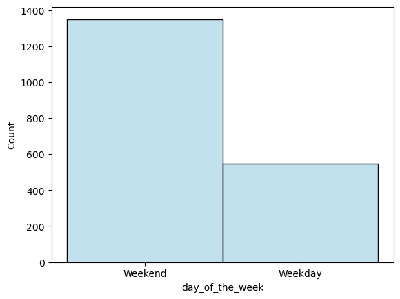

```python
sns.histplot(data=df, x='day_of_the_week', color='lightblue')
```

- Day_of_the_week consists in two unique values: Weekend and weekday.
- As we can see in the plot, the distribution shows that the number of order placed during weekends is more than double of orders placed during week days.
- There is a considerable increase in the number of orders placed by customers on weekends.

### Rating

```python
df['rating'].value_counts()
```

```
rating
Not given    736
5            588
4            386
3            188
Name: count, dtype: int64
```

- There are 736 orders rated with 'not given', 588 rated with '5', 386 rated with '4' and 188 rated with '3'

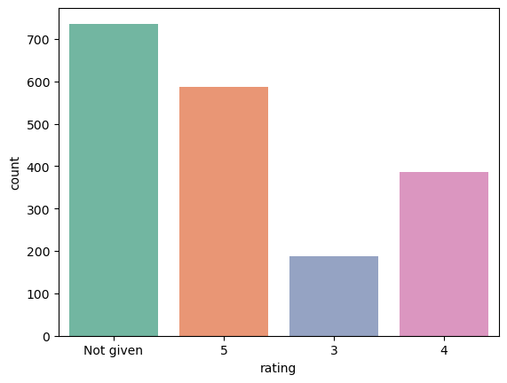

```python
sns.countplot(data=df, x='rating', palette='Set2', hue='rating')
```

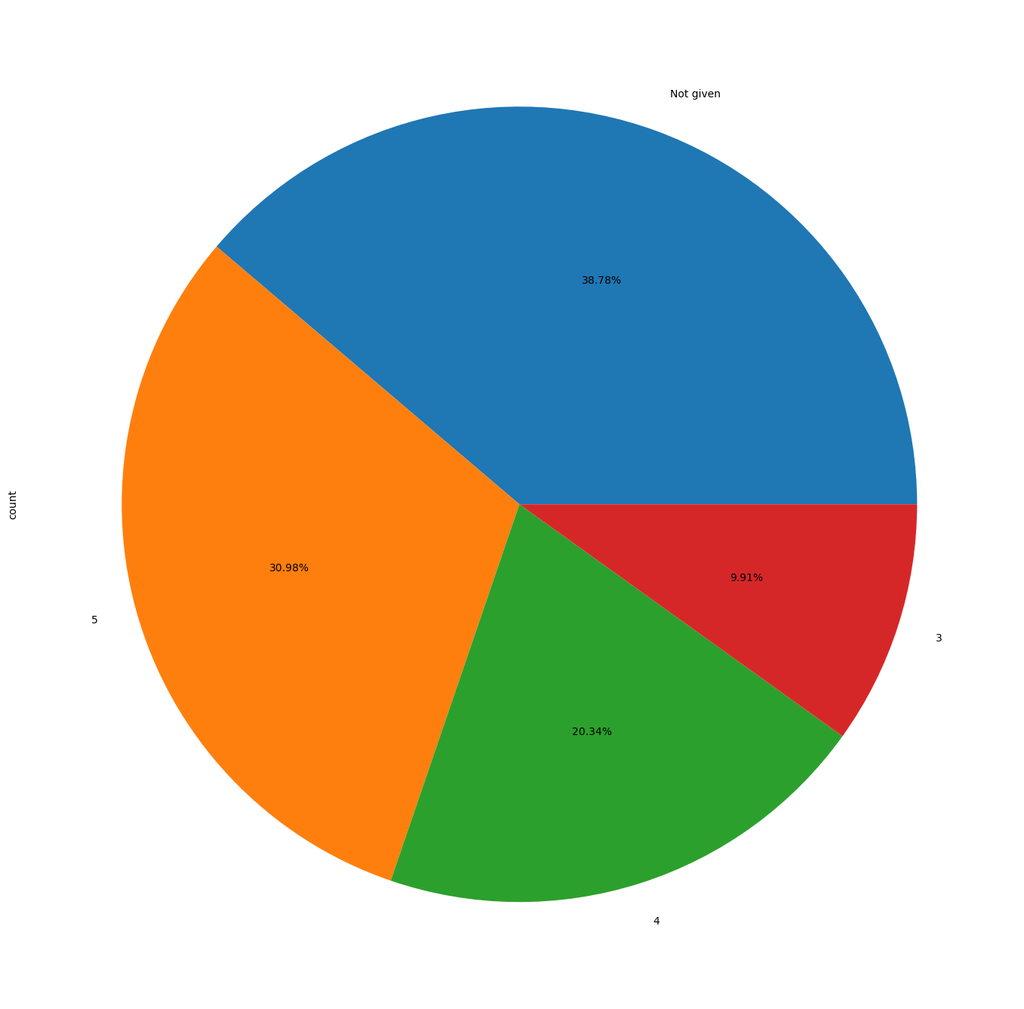

```python
# Plotting pie chart. autopct formating the percentage with two decimal values
df['rating'].value_counts().plot(kind='pie', autopct='%1.2f%%',figsize=(17,20))
```

```python
df.loc[df['rating'] != 'Not given']['rating'].dropna().describe()
```

```
count     1162
unique       3
top          5
freq       588
Name: rating, dtype: object
```

- The distribution shows that the most frequent category is 'not given' with 736 orders rated followed by 5 with 588 orders rated.
- 'Not given' and '5' represents almost the 70% of the total of orders rated.
- Dropping 'Not given' value, the top rating is 5.
- Around 10% of the orders were rated low.

### Food preparation time

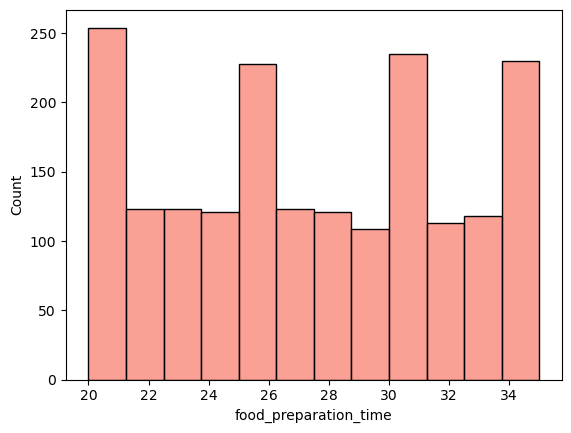

```python
sns.histplot(data=df, x='food_preparation_time', color='salmon')
plt.show()
```

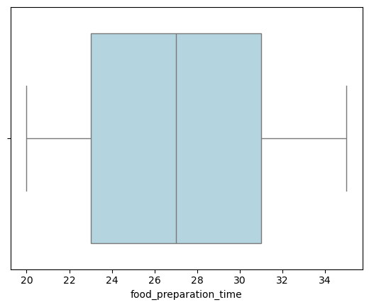

```python
sns.boxplot(data=df, x='food_preparation_time', color='lightblue')
plt.show()
```

```python
df['food_preparation_time'].describe()
```

```
count    1898.000000
mean       27.371970
std         4.632481
min        20.000000
25%        23.000000
50%        27.000000
75%        31.000000
max        35.000000
Name: food_preparation_time, dtype: float64
```

- The median is almost equal to the mean in the data set so it indicates the data is approximately symmetric and not heavily skewed.
- There are no outliers in this column.
- The minimum value of food preparation time in minutes is 20 and the maximum is 35.

### Delivery time

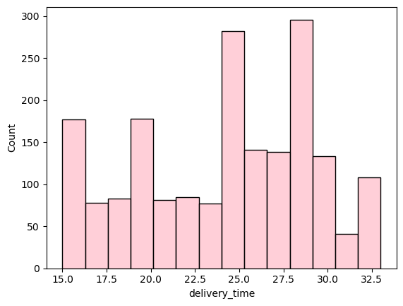

```python
sns.histplot(data=df, x='delivery_time', color='pink')
plt.show()
```

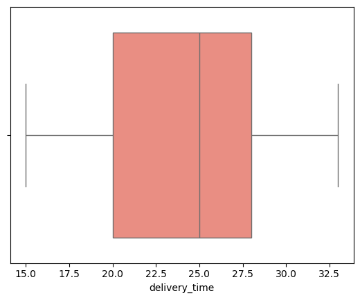

```python
sns.boxplot(data=df, x='delivery_time', color='salmon')
plt.show()
```

```python
df['delivery_time'].describe()
```

```
count    1898.000000
mean       24.161749
std         4.972637
min        15.000000
25%        20.000000
50%        25.000000
75%        28.000000
max        33.000000
Name: delivery_time, dtype: float64
```

- The mean(24.2min) is a bit smaller than the median(25) so that indicates the distribution is a bit left-skewed.
- In the boxplot we can evidence that the median is a bit closer to Q3 indicating higher concentration of data points in this part.
- In the histogram there's a longer left tail.
- There are no outliers.
- Most of the orders have delivery time between 24 - 28 minutes.

### **Question 7**: Which are the top 5 restaurants in terms of the number of orders received? [1 mark]

```python
# Write the code here
# Group by restaurant name and order_id since order_id is a unique identifier and then count/sort and display the top 5
df.groupby('restaurant_name')['order_id'].count().sort_values(ascending=False).head(5)
```

```
restaurant_name
Shake Shack                  219
The Meatball Shop            132
Blue Ribbon Sushi            119
Blue Ribbon Fried Chicken     96
Parm                          68
Name: order_id, dtype: int64
```

```python
# Sum all the orders to have a total of orders placed in these top 5 restaurants
df.groupby('restaurant_name')['order_id'].count().sort_values(ascending=False).head(5).sum()
```

```
634
```

```python
# Finding the percetage of orders receieved of these 5 restaurants
((df.groupby('restaurant_name')['order_id'].count().sort_values(ascending=False).head(5).sum())/df.shape[0])*100
```

```
33.40358271865121
```

### **Question 8**: Which is the most popular cuisine on weekends? [1 mark]

```python
# Write the code here

#Filtering column day of the week by Weekend
df_weekend = df[df['day_of_the_week'] == 'Weekend']
#Counting each cuisine type with this filter applied
df_weekend['cuisine_type'].value_counts()
```

```
cuisine_type
American          415
Japanese          335
Italian           207
Chinese           163
Mexican            53
Indian             49
Mediterranean      32
Middle Eastern     32
Thai               15
French             13
Korean             11
Southern           11
Spanish            11
Vietnamese          4
Name: count, dtype: int64
```

#### Observations:

- The most popular cuisine on weekends is American with 415 orders placed during weekends out of 584.

### **Question 9**: What percentage of the orders cost more than 20 dollars? [2 marks]

```python
# Write the code here

#Filtering the orders that costs more than 20 dollars
orders_more_than_20 = df[df['cost_of_the_order'] > 20]
#Using len to find the number of rows with this filter
total_of_orders_more_than_20 = len(orders_more_than_20)
# Finding the percentage taking the new variable and the number of rows in total of cost of the order
percentage_more_twenty_dollars = (total_of_orders_more_than_20/len(df['cost_of_the_order']))*100
print(percentage_more_twenty_dollars, '%')
print(total_of_orders_more_than_20)
```

```
29.24130663856691 %
555
```

#### Observations:

- There are a total of 555 of orders that cost above 20 dollars.
- The percentage of these orders in the database is 29.24

### **Question 10**: What is the mean order delivery time? [1 mark]

```python
# Write the code here
#Using the method .mean() and rounded to 3 decimals
mean_delivery_time = round(df['delivery_time'].mean(), 3)
print('The mean delivery time for this dataset is', mean_delivery_time , 'minutes')
```

```
The mean delivery time for this dataset is 24.162 minutes
```

```python
# describe() also displays the mean of the numerical variables in the dataset
df.describe()
```

|  | order_id | customer_id | cost_of_the_order | food_preparation_time | delivery_time |
| --- | --- | --- | --- | --- | --- |
| count | 1.898000e+03 | 1898.000000 | 1898.000000 | 1898.000000 | 1898.000000 |
| mean | 1.477496e+06 | 171168.478398 | 16.498851 | 27.371970 | 24.161749 |
| std | 5.480497e+02 | 113698.139743 | 7.483812 | 4.632481 | 4.972637 |
| min | 1.476547e+06 | 1311.000000 | 4.470000 | 20.000000 | 15.000000 |
| 25% | 1.477021e+06 | 77787.750000 | 12.080000 | 23.000000 | 20.000000 |
| 50% | 1.477496e+06 | 128600.000000 | 14.140000 | 27.000000 | 25.000000 |
| 75% | 1.477970e+06 | 270525.000000 | 22.297500 | 31.000000 | 28.000000 |
| max | 1.478444e+06 | 405334.000000 | 35.410000 | 35.000000 | 33.000000 |

#### Observations:

The mean delivery time is 24.16 minutes approximately.

### **Question 11:** The company has decided to give 20% discount vouchers to the top 3 most frequent customers. Find the IDs of these customers and the number of orders they placed. [1 mark]

```python
# Write the code here
#Since each customer have a unique customer id with value count it's posible count the frequency of each row in the data set and
# head(3) display the top 3
top_3_frequent_customers = df['customer_id'].value_counts().head(3)
print(top_3_frequent_customers)
```

```
customer_id
52832    13
47440    10
83287     9
Name: count, dtype: int64
```

#### Observations:

The top 3 most frequent customers are:

- Customer_id: 52832 with 13 orders
- Customer_id: 47440 with 10 orders
- Customer_id: 83287 with 9 orders

The customer id's mentioned below are the ones that will recieve 20% discount.

### **Question 12**: Perform a multivariate analysis to explore relationships between the important variables in the dataset. (It is a good idea to explore relations between numerical variables as well as relations between numerical and categorical variables) [10 marks]

```python
# Checking all the variables to choose and explore relations between them
df.info()
```

```
<class 'pandas.core.frame.DataFrame'>
RangeIndex: 1898 entries, 0 to 1897
Data columns (total 9 columns):
 #   Column                 Non-Null Count  Dtype
---  ------                 --------------  -----
 0   order_id               1898 non-null   int64
 1   customer_id            1898 non-null   int64
 2   restaurant_name        1898 non-null   object
 3   cuisine_type           1898 non-null   object
 4   cost_of_the_order      1898 non-null   float64
 5   day_of_the_week        1898 non-null   object
 6   rating                 1898 non-null   object
 7   food_preparation_time  1898 non-null   int64
 8   delivery_time          1898 non-null   int64
dtypes: float64(1), int64(4), object(4)
memory usage: 133.6+ KB
```

### Cost of the order - Rating

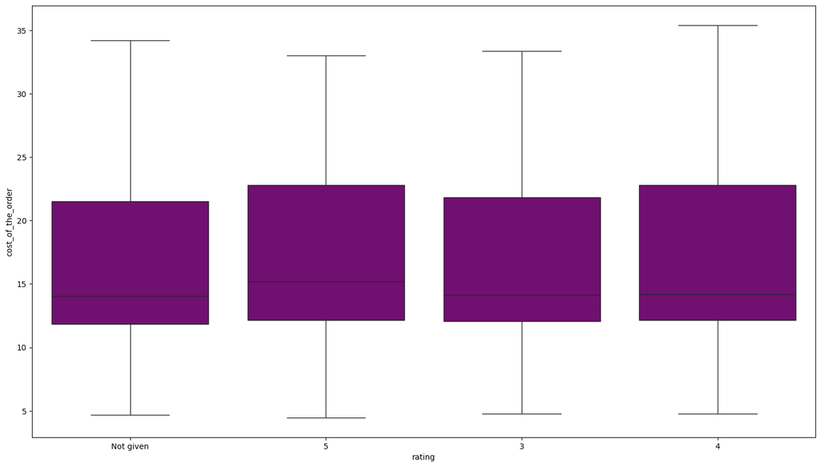

```python
plt.figure(figsize=(18,10))
sns.boxplot(x='rating', y='cost_of_the_order',data=df, color='purple')
```

- There are no outliers. All points are within the whiskeys.
- The median cost of the order for each rating score is similar.
- The box sizes are similar indicating that the distribution of costs for different ratings is uniform.

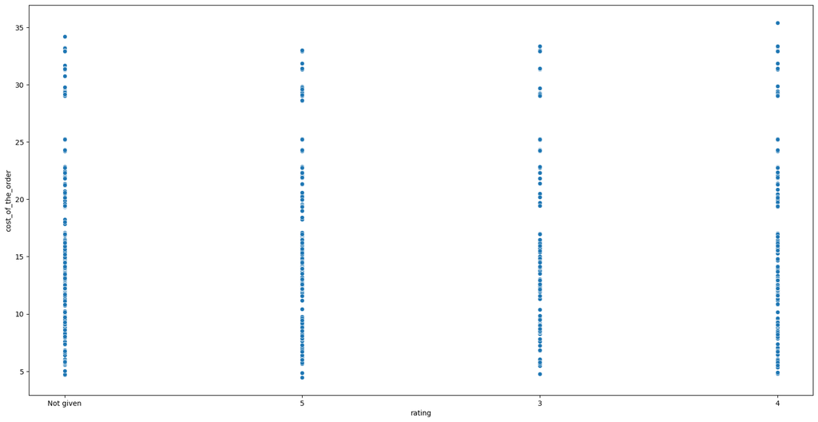

```python
plt.figure(figsize=(20,10))
sns.scatterplot(x='rating',y='cost_of_the_order',data=df)
plt.show()
```

- There is no a clear pattern or correlation with the cost of the order and the rating.

```python
#Create a new column excluding not given value to calculate the correlation
df['rating_exclude_notgiven'] = df.loc[df['rating'] != 'Not given']['rating'].dropna()
# Finding correlation between cost of the order and rating
corr_cost_rating= df[['cost_of_the_order','rating_exclude_notgiven']].corr()
print(corr_cost_rating)
# deleting the column to do not alter the original data set
del df['rating_exclude_notgiven']
```

```
                         cost_of_the_order  rating_exclude_notgiven
cost_of_the_order                 1.000000                 0.033983
rating_exclude_notgiven           0.033983                 1.000000
```

- Correlation of 0.034 indicates there's no correlation, changing cost of the order doesn't impact significantly on the rating.

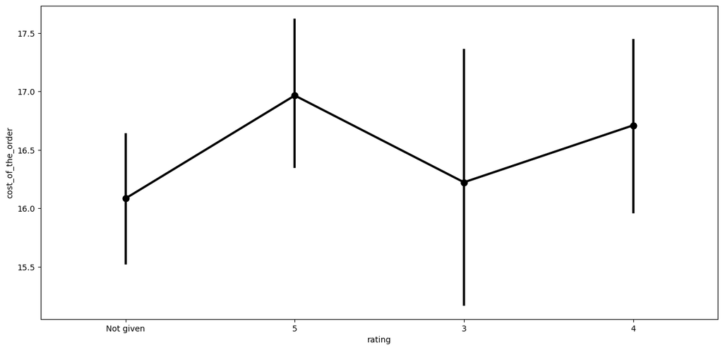

```python
plt.figure(figsize=(15,7))
sns.pointplot(x='rating', y='cost_of_the_order',data=df, color='Black')
```

### Cuisine type - Cost of the order

[output not shown]

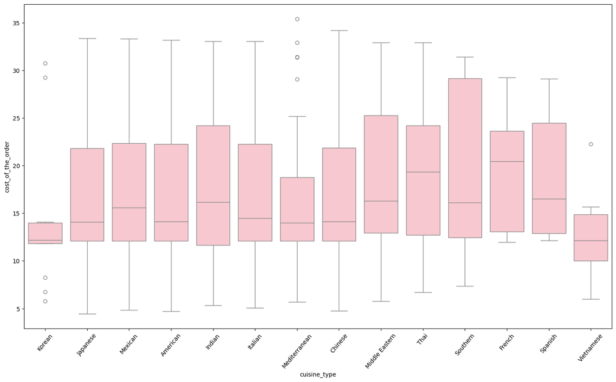

```python
plt.figure(figsize=(18,10))
sns.boxplot(x='cuisine_type', y='cost_of_the_order',data=df, color='pink')
plt.xticks(rotation=50)
```

### Observations:

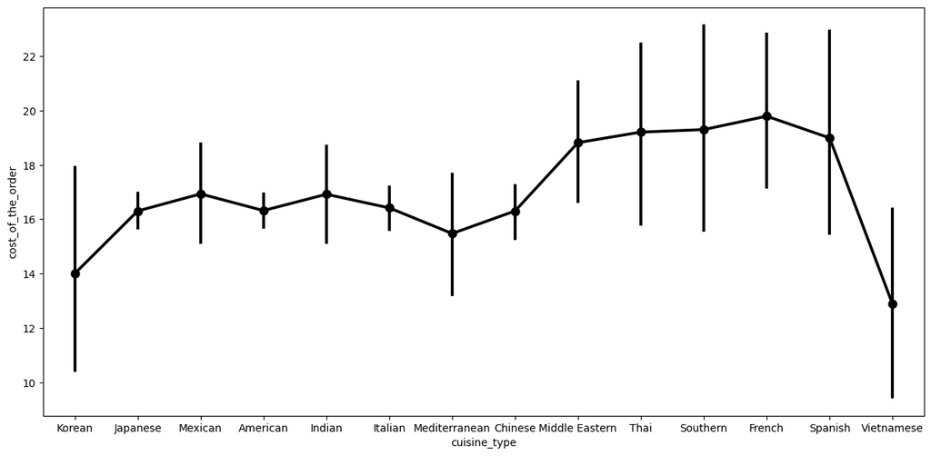

```python
plt.figure(figsize=(15,7))
sns.pointplot(x='cuisine_type', y='cost_of_the_order',data=df, color='Black')
```

- Korean and vietamese cusine have the lowest average cost of order.
- French cuisine seems to have the higher average cost.
- Japense, American and Italian cuisines have shorter error bars indicating that the costs are more consistent.

### Cuisine type - food preparation time

[output not shown]

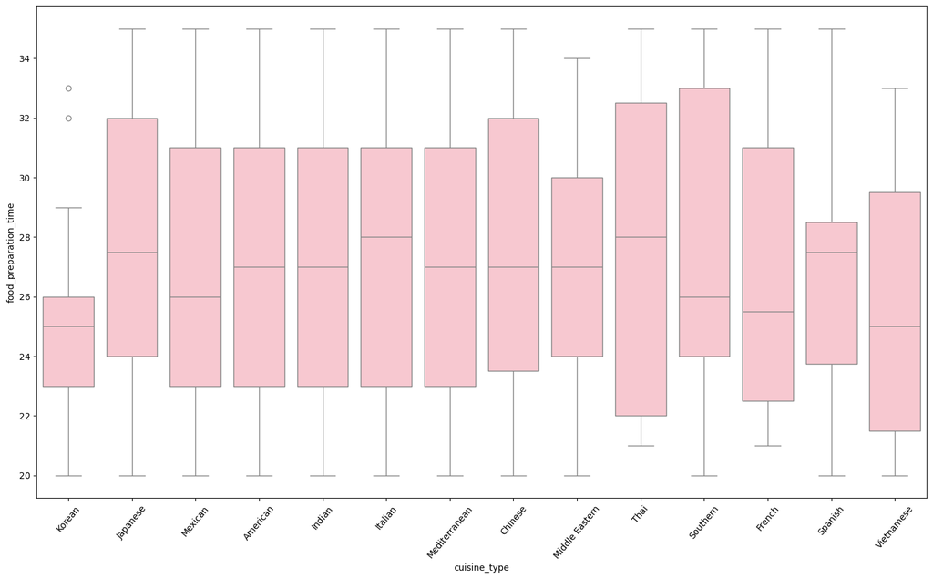

```python
plt.figure(figsize=(18,10))
sns.boxplot(x='cuisine_type', y='food_preparation_time',data=df, color='pink')
plt.xticks(rotation=50)
```

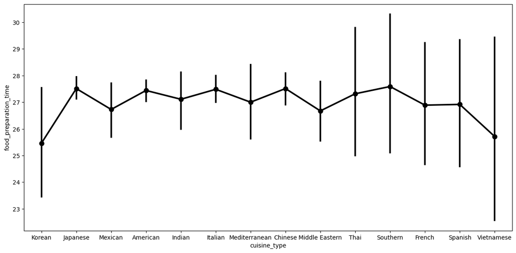

```python
plt.figure(figsize=(15,7))
sns.pointplot(x='cuisine_type', y='food_preparation_time',data=df, color='Black')
```

### Day of the week - Delivery time

```
([0, 1], [Text(0, 0, 'Weekend'), Text(1, 0, 'Weekday')])
```

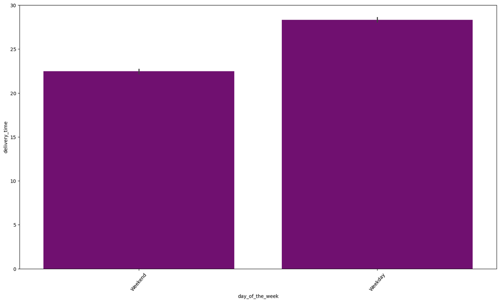

```python
plt.figure(figsize=(18,10))
sns.barplot(x='day_of_the_week', y='delivery_time',data=df, color='purple')
plt.xticks(rotation=50)
```

- The mean delivery time during weekend is around 22.5 minutes.
- The mean delivery time during week days is around 28 minutes.

```
([0, 1], [Text(0, 0, 'Weekend'), Text(1, 0, 'Weekday')])
```

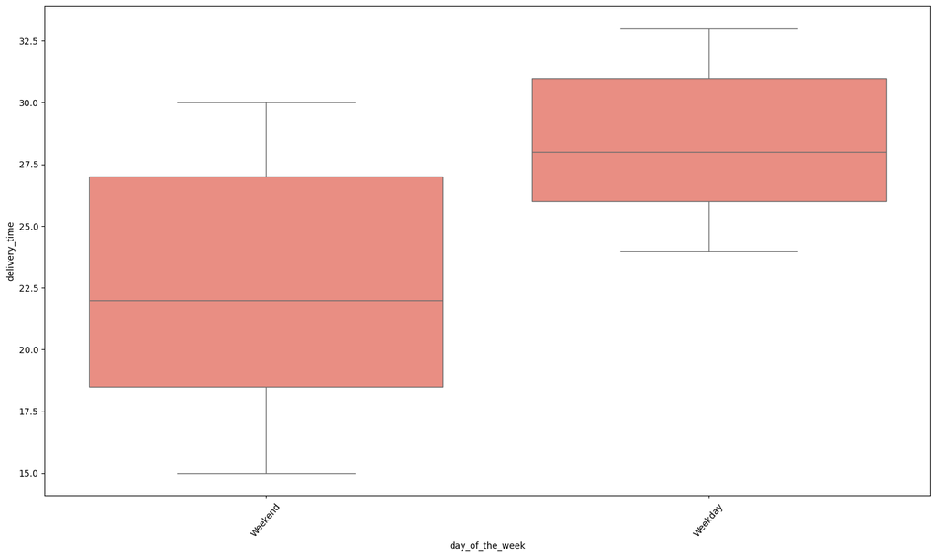

```python
plt.figure(figsize=(18,10))
sns.boxplot(x='day_of_the_week', y='delivery_time',data=df, color='salmon')
plt.xticks(rotation=50)
```

### Rating - Delivery time

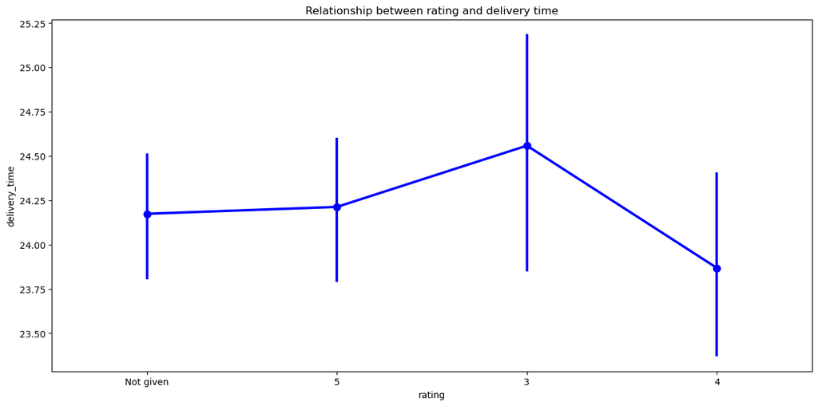

```python
plt.figure(figsize=(15,7))
sns.pointplot(x='rating', y='delivery_time',data=df, color='blue')
plt.title("Relationship between rating and delivery time")
```

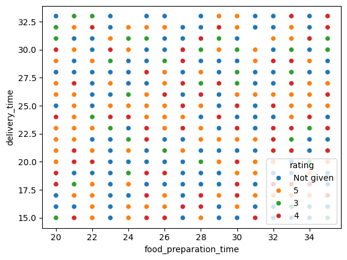

```python
sns.scatterplot(x='food_preparation_time', y='delivery_time', hue='rating', data=df)
```

### Observations

- The range of error bars indicates that within each rating category, there is a significant variance in delivery time.
- It appears that ratings like 4 or 5 have a range delivery time of 23.5min to 24.7min maximum. On the other hand rating 3 has a longer delivery time that varies from 24 minutes to more than 25 minutes.
- It is possible that longer waiting times may have an impact on the rating score.
- In the scatterplot doesn't seem to have a linear relationship between food preparation and delivery time, there's no a clear pattern.
- The plot shows points scattered broadly.
- Delivery time seem to vary a lot even for same for preparation time, evidencing that food preparation time doesn't determine delivery time.
- Factors influencing rating might be more complex than just delivery time and food preparation time.

### Rating - Food preparation time

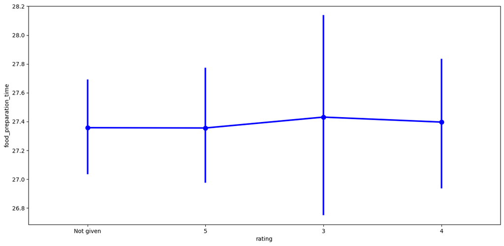

```python
plt.figure(figsize=(15,7))
sns.pointplot(x='rating', y='food_preparation_time',data=df, color='blue')
```

### Observations

- Food preparation time doesn't impact that much the rating score.

### DAY OF THE WEEK - COST OF THE ORDER - CUISINE TYPE

```
([0, 1], [Text(0, 0, 'Weekend'), Text(1, 0, 'Weekday')])
```

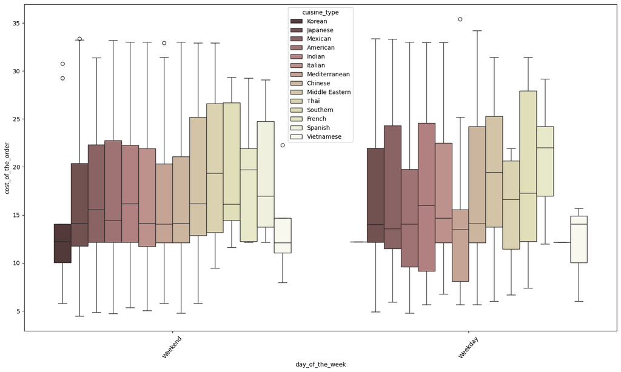

```python
plt.figure(figsize=(18,10))
sns.boxplot(x='day_of_the_week', y='cost_of_the_order', hue='cuisine_type',data=df, palette='pink')
plt.xticks(rotation=50)
```

### Correlation between variables

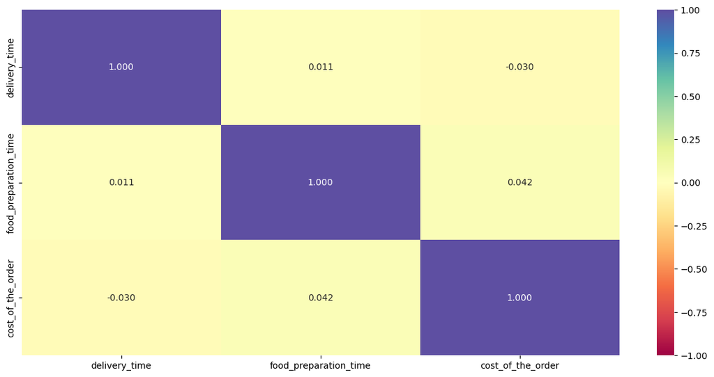

```python
col_list = ['delivery_time','food_preparation_time', 'cost_of_the_order']
plt.figure(figsize=(15,7))
sns.heatmap(df[col_list].corr(), annot=True, vmin=-1, vmax=1, fmt=".3f",cmap="Spectral")
plt.show()
```

### Observations

- There is no correlation between delivery_time, food_preparation_time and cost_of_the_order.
- Delivery time and food preparation time. Correlation of 0.01 indicates there's no correlation, changing food preparation time doesn't impact significantly on delivery time.
- Delivery time and cost of the order. Correlation -0.03. Negative correlation indicates there's no correlation, it is very weak, no meaningful relationship between these two variables.
- Food preparation time and cost of the order. Correlation 0.04. It has a low positive correlation indicating a very minimal relationship.
- There's a lack of strong correlation.

### **Question 13:** The company wants to provide a promotional offer in the advertisement of the restaurants. The condition to get the offer is that the restaurants must have a rating count of more than 50 and the average rating should be greater than 4. Find the restaurants fulfilling the criteria to get the promotional offer. [3 marks]

```python
# Filtering rows where the rating is not given
df_rated = df[df['rating'] != 'Not given'].copy()
# Convert rating to integer type
df_rated['rating'] = df_rated['rating'].astype(int)

# Rating count per restaurant
df_rating_count = df_rated.groupby('restaurant_name')['rating'].count().reset_index()

# Step 3: Filter for restaurants with rating count > 50. Condition 1
df_50_count = df_rating_count[df_rating_count['rating'] > 50]

# Merging df_50_count with df_rated to get the restaurants with count > 50
df_merge_rating_50 = pd.merge(df_rated, df_50_count[['restaurant_name']], on='restaurant_name')

# Calculating the mean rating for each restaurant in the filtered list
df_mean_rating_4 = df_merge_rating_50.groupby('restaurant_name')['rating'].mean().reset_index()

#Filter for restaurants with an average rating greater than 4. Condition 2
restaurants_criteria = df_mean_rating_4[df_mean_rating_4['rating'] > 4].sort_values(by='rating', ascending=False)

# Print the restaurants that fulfill the criteria
print(" Restaurants fulfilling the criteria to get the promotional offer are:")
print(restaurants_criteria)
```

```
 Restaurants fulfilling the criteria to get the promotional offer are:
             restaurant_name    rating
3          The Meatball Shop  4.511905
0  Blue Ribbon Fried Chicken  4.328125
2                Shake Shack  4.278195
1          Blue Ribbon Sushi  4.219178
```

#### Observations:

- The restaurants that fulfill the criteria (rating count more than 50 and average rating greater than 4) to get the promotional offer are: The meatball shop, Blue Ribbon Fried Chicken, Shake Shack, Blue Ribbon Sushi. All of them have a rating count more than 50 and average above 4.

### **Question 14:** The company charges the restaurant 25% on the orders having cost greater than 20 dollars and 15% on the orders having cost greater than 5 dollars. Find the net revenue generated by the company across all orders. [3 marks]

```python
# Write the code here

#Filter the orders having cost greater than 20 dollars
df_cost_more_20 =  df[df['cost_of_the_order'] > 20].copy()
#Filter the orders having cost greater than 5 dollars and less or equal than 20
df_cost_more_5 = df[(df['cost_of_the_order'] > 5) & (df['cost_of_the_order'] <= 20)].copy()

# Calculating the charge of 25% or 15% accordingly
revenue1= (df_cost_more_20['cost_of_the_order']*0.25).sum()
revenue2= (df_cost_more_5['cost_of_the_order']*0.15).sum()
#Calculating total revenue
revenue_total = revenue1 + revenue2
print(revenue_total)
```

```
6166.303
```

#### Observations:

The net revenue generated on all the orders given in the dataset is 6166.3 dollars.

### **Question 15:** The company wants to analyze the total time required to deliver the food. What percentage of orders take more than 60 minutes to get delivered from the time the order is placed? (The food has to be prepared and then delivered.) [2 marks]

```python
# Write the code here

#Adding new column to the dataframe df to store delivery time + preparation time
df['total_time'] = df['food_preparation_time']+ df['delivery_time']
#Filtering the number of orders that take more than 60 minutes to get delivered from the time the order
number_orders_more_60 = len(df[df['total_time']>60])

#Percentage
print('The percentage of orders that take more than 60 minutes to get delivered from the time the order is placed is',
      round((number_orders_more_60/len(df))*100,2), '%')
# Deleting the column created
del df['total_time']
```

```
The percentage of orders that take more than 60 minutes to get delivered from the time the order is placed is 10.54 %
```

#### Observations:

10,54% of the total of orders take more than 60 minutes to get delivered including food preparation time and delivery time.

### **Question 16:** The company wants to analyze the delivery time of the orders on weekdays and weekends. How does the mean delivery time vary during weekdays and weekends? [2 marks]

```python
# Write the code here

# mean delivery time in week days
mean_weekday= round(df[df['day_of_the_week']== 'Weekday']['delivery_time'].mean(),2)
# mean delivery time on weekend
mean_weekend= round(df[df['day_of_the_week']== 'Weekend']['delivery_time'].mean(),2)

print('The mean delivery time on week days is', mean_weekday, 'minutes.')
print('The mean delivery time on weekends is', mean_weekend, 'minutes.')
```

```
The mean delivery time on week days is 28.34 minutes.
The mean delivery time on weekends is 22.47 minutes.
```

#### Observations:

- The mean delivery time on week days is around 28 minutes, however the mean deliery time on weekends is around 22min. It indicates that on weekends the service is faster.
- This could be explained by the fact that traffic on weekdays is greater than on weekends.

### Conclusion and Recommendations

### **Question 17:** What are your conclusions from the analysis? What recommendations would you like to share to help improve the business? (You can use cuisine type and feedback ratings to drive your business recommendations.) [6 marks]

### Conclusions:

- The number of orders placed on weekends is much higher than during weekdays, more than double.
- Delivery time is shorter during weekends than during weekdays, this can be explained by the fact that there may be a reduction in city traffic on non-working days.
- Shake shack is the most popular restaurant, it has recieved the larger number of orders followed by The Meatball shop.
- The most popular cuisines during weekends and weekdays are American and Japanese.
- The most frequent cuisine is American with 30.8% followed by Japanese with 24.8% and Italian cuisine 15.7%. It seems that these 3 cuisines have about 70% of Foodhub's order number.
- Around 39% of the orders have not been rated and around 30% are rated with 5 score.

### Recommendations:

- Foodhub should incorporate more American, Japanese and Italian restaurants to continue attracting customers as these 3 cuisines are the most popular.
- Foodhub should pay more attention to developing strategies for all customers to take satisfaction surveys in order to have a clear picture of how to improve or where they are doing a great job. In addition, in order to identify a pattern in what is failing, questions related to delivery time, food preparation time, food quality and food presentation should be included.
- To increase the number of orders during the weekdays, promotional offers should be included.
- As the number of orders is higher during the weekends, FoodHub must ensure that it has enough staff to deliver all orders without any setbacks.
- Foodhub must investigate the reason why customers are giving low ratings to tackle the root problem.
- Around 10,54% of the total of orders take more than 60 minutes to get delivered. Foodhub should try to minimize the time to maintain customer satisfaction. It should contact the restaurants to establish the maximum preparation times and with the delivery people the maximum delivery times, thus seeking improvement in each of the instances.
- Establishing maximum or standard times helps each of the parts of the supply chain adjust to achieve them.
- Foodhub should talk to Spanish and Vietnamese restaurants to include promotional offers and attract more customers, these two cuisines being the least popular.
- Foodhub should continue to encourage orders from customers' favorite restaurants such as Shake Shack and The Meatball Shop by providing increased visibility and promotional codes after certain purchases.